# Scripted HTML

Tim Bergsma

2024-03-18

The point of this exercise is to demonstrate flexible rendering of subscripts and superscripts. We want to write expressions for column labels and units that are fairly readable as they are, and yet can be easily rendered with equivalent results in plotmath, html, or pdf.

First we load some packages.

```r
library(magrittr)
library(ggplot2)
library(tablet)
library(yamlet)
```

We create some toy data.

```r
x <- data.frame(time = 1:10, work = (1:10)^1.5)
x %<>% decorate('
 time: [ Time_cum.^alpha, h ]
 work: [ Work_total_obs, kg*m^2/s^2 ]
')
x %>% decorations
```

```
## - time
##  - label: Time_cum.^alpha
##  - guide: h
## - work
##  - label: Work_total_obs
##  - guide: kg*m^2/s^2
```

Notice that the label for column `work` has nested subscripts: *obs* is subordinate to *total*, and the result is subordinate to *Work*.

For the column `time`, the word *Time* is followed by a subscript *cum*. Then, *cum* is followed by the superscript *alpha*. In this case *alpha* intends to be the superscript of *Time_cum* not just *cum*. We include the dot to explicitly terminate the *cum* subscript, which causes *alpha* to be the superscript of the combined result.

How does this look when we plot it?

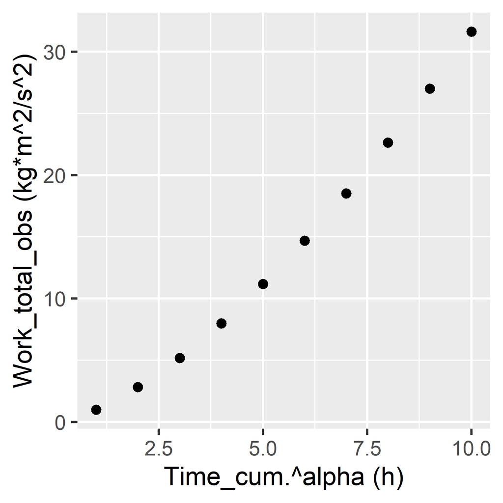

```r
x %>% resolve %>% ggplot(aes(time, work)) + geom_point()
```

By default, we get verbatim labels and units as substitutes for column names.

Next, we use `scripted()` instead of `resolve()` to indicate that the labels should be understood as potentially having subscripts and superscripts. For this to work well, units should be constructed using *, /, and ^ (even though the “units” package supports other encodings).

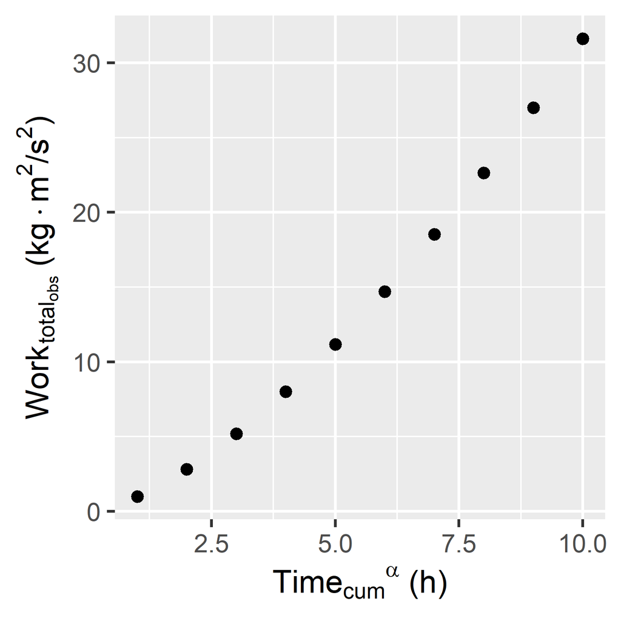

```r
x %>% scripted %>% ggplot(aes(time, work)) + geom_point()
```

In the background, `scripted()` is writing **expression** attributes (consumed by `ggplot()` ) and **title** attributes (consumed by `tablet()` ). We illustrate the latter.

```r
x %>% scripted %>% tablet %>% as_kable
```

|  | All (N = 10) |
| --- | --- |
| **Time<sub>cum</sub><sup>α</sup> (h)** |  |
| Mean (SD) | 5.5 (3.03) |
| Median (range) | 5.5 (1, 10) |
| **Work<sub>total<sub>obs</sub></sub> (kg·m<sup>2</sup>/s<sup>2</sup>)** |  |
| Mean (SD) | 14.3 (10.5) |
| Median (range) | 12.9 (1, 31.6) |

In summary, we have decorated our data with labels and units containing markup for subscripts and superscripts. If everything goes well, these render similarly in figures and tables. They also render similarly in html and pdf. Please see the pdf version of this document.

[output not shown]